# Assignment 7: Constructing Likelihood Ratio Confidence Interval

Samuel Johnson

Due: March, 2026

## **Assignment Objectives**

- Reinforce the likelihood concepts and MLE.
- Understand the concepts of confidence intervals.
- Master the process of finding likelihood ratio confidence interval of unknown parameter.

## **Policies of Using AI Tools**

**Policy on AI Tool Use**: You must adhere to the AI tool policy specified in the course syllabus. The direct copying of AI-generated content is strictly prohibited. All submitted work must reflect your own understanding; where external tools are consulted, content must be thoroughly rephrased and synthesized in your own words.

**Code Inclusion Requirement**: Any code included in your essay must be properly commented to explain the purpose and/or expected output of key code lines. Submitting AI-generated code without meaningful, student-added comments will not be accepted.

**One Parameter Lindley Distribution**

The **Lindley distribution** is a **continuous probability distribution** proposed by D.V. Lindley in 1958. It represents a **weighted mixture** of exponential and gamma distributions, providing a flexible single-parameter model for lifetime data.

$$f(x;\theta) = \frac{\theta^2}{1+\theta}(1+x)e^{-\theta x}, \quad x >
0, \quad \theta > 0$$

where $x$ = random variable (e.g., time, size, amount) and $\theta$ = shape parameter controlling the distribution.

Given an independent random sample $X_1, X_2, \dots, X_n$:

$$L(\theta) = \prod_{i=1}^n f(x_i;\theta) = \prod_{i=1}^n \left[
\frac{\theta^2}{1+\theta} (1 + x_i) e^{-\theta x_i} \right].$$

Let $S = \sum_{i=1}^n x_i$, $\bar{x} = S/n$, and $C = \sum_{i=1}^n \ln(1 + x_i)$ (constant with respect to $\theta$):

$$\ell(\theta) = \ln L(\theta) = n \ln\left( \frac{\theta^2}{1+\theta}
\right) + C - \theta S.$$

After some algebra, we obtain the closed form of the MLE of $\theta$ in the following

$$\boxed{\hat{\theta} = \frac{1 - \bar{x} + \sqrt{\bar{x}^2 + 6\bar{x} +
1}}{2\bar{x}}}$$

As good exercise, we can derive the following Fisher information of $\theta$:

$$\boxed{I(\theta) = \frac{2}{\theta^2} - \frac{1}{(1+\theta)^2}}$$

**This assignment focuses on constructing various confidence intervals of the shape parameter $\theta$ in the Lindley distribution.**

## **Question: Customer Service Times (minutes)**

The customer service call duration data set originates from a major telecommunications provider in North America, operating in a highly competitive market where:

```
3.2, 5.8, 7.1, 4.5, 10.3, 6.2, 8.7, 5.1, 12.5, 6.9,
9.4, 5.7, 11.8, 4.9, 9.1, 6.5, 13.2, 7.8, 10.6, 6.1,
8.9, 5.4, 12.1, 7.3, 9.8, 5.9, 11.4, 6.8, 10.9, 7.5,
4.2, 8.3, 6.4, 14.1, 5.6, 9.7, 7.9, 11.1, 6.7, 10.2,
5.3, 8.6, 7.2, 12.9, 6.3, 9.3, 8.1, 13.7, 7.6, 10.8
```

Assuming the data follow a one-parameter Lindley distribution, construct a $95\%$ confidence interval for the parameter $\theta$ using the provided data and the specified methods. For each of the following questions, first describe your reasoning process for the analysis, then write code to perform the actual analysis. Finally, summarize the results to conclude the question.

1. Construct a **95% asymptotic confidence interval** based on the asymptotic sampling distribution of the maximum likelihood estimator (MLE) of $\theta$.
   From the lecture notes, we know that the MLE estimator of parameter $\theta$ is normally distributed,
   $$\hat{\theta} \sim \mathcal{N} \left(\theta,
   \widehat{\text{var}}(\hat{\theta})\right) \Leftrightarrow
   \frac{\hat{\theta} -
   \theta}{\sqrt{\widehat{Var}(\hat{\theta})}} \sim
   \mathcal{N}(0,1)$$
   At significance level $\alpha = 0.05$,

$$\begin{eqnarray*}
1 - \alpha &=& 0.95\\ &=& P \left(\left|
\frac{\hat{\theta} -
\theta}{\sqrt{\widehat{Var}(\hat{\theta})}} \right| < z_{1-
\frac{\alpha}{2}}\right)\\
&=& P \left(z_{\frac{\alpha}{2}} < \frac{\hat{\theta} -
\theta}{\sqrt{\widehat{Var}(\hat{\theta})}} < z_{1- \frac{\alpha}{2}}
\right)\\
&\Rightarrow&\\
z_{\frac{\alpha}{2}} \sqrt{\widehat{Var}(\hat{\theta})} <&
\hat{\theta} - \theta & < z_{1-\frac{\alpha}{2}}
\sqrt{\widehat{Var}(\hat{\theta})}\\
&\Leftrightarrow&\\
z_{\frac{\alpha}{2}} \sqrt{\widehat{Var}(\hat{\theta})} - \hat{\theta}
<& - \theta & < z_{1-\frac{\alpha}{2}}
\sqrt{\widehat{Var}(\hat{\theta})} - \hat{\theta}\\
&\Leftrightarrow&\\
\hat{\theta} - z_{1-\frac{\alpha}{2}}
\sqrt{\widehat{Var}(\hat{\theta})}<& \theta & <
\hat{\theta} - z_{\frac{\alpha}{2}} \sqrt{\widehat{Var}(\hat{\theta})}
\end{eqnarray*}$$

where $z_a$ denotes the $a \times 100\%$ quantile of the standard normal distribution $\mathcal{N}(0, 1)$
Note that,
$$\widehat{Var}(\hat{\theta}) = \frac{1}{I_n(\hat{\theta})}$$
Where,
$$I_n (\hat{\theta}) = n I(\hat{\theta})$$

```r
X <- c(3.2, 5.8, 7.1, 4.5, 10.3, 6.2, 8.7, 5.1, 12.5, 6.9,
9.4, 5.7, 11.8, 4.9, 9.1, 6.5, 13.2, 7.8, 10.6, 6.1,
8.9, 5.4, 12.1, 7.3, 9.8, 5.9, 11.4, 6.8, 10.9, 7.5,
4.2, 8.3, 6.4, 14.1, 5.6, 9.7, 7.9, 11.1, 6.7, 10.2,
5.3, 8.6, 7.2, 12.9, 6.3, 9.3, 8.1, 13.7, 7.6, 10.8)


theta_mle <- function(X){
  x_bar <- mean(X)
  (1 - x_bar  + sqrt(x_bar^2 + 6 * x_bar + 1)) / (2 * x_bar)
}

fisher_information <- function(theta){
  2 / theta^2 - (1 + theta )^-2
}

#find theta hat
theta_hat <- theta_mle(X)

#find \widehat{var}(\hat{\theta})
#Note, the definition for fisher information provided above
#appears to only be for a single element of the sample
#thus we must scale it by n
#see DOI:10.15672/HJMS.201611615850 section 5
mle_var <- 1 / fisher_information(theta_hat) / length(X)

alpha <- 0.05

lower_bound <- theta_hat - qnorm(1 - alpha/2) * sqrt(mle_var)
upper_bound <- theta_hat - qnorm(alpha/2) * sqrt(mle_var)

cat("(",lower_bound, ",", upper_bound,")")
```

```
( 0.1758057 , 0.2623931 )
```

2. Construct a **95% likelihood ratio confidence interval** for $\theta$.

We know that $LR(\theta) = -2 \log \Lambda(\theta) = 2 \left[l(\theta_{\text{MLE}}; x) - l(\theta;x) \right] \sim \chi^2_1$ where,
$$\Lambda(\theta) =
\frac{L(\theta;x)}{L(\theta_{\text{MLE}};x)}$$

We wish to bound $\theta$, to this end

$$\begin{eqnarray*}
2\left[l(\hat{\theta}_{\text{MLE}}) - l(\theta)\right] &=&
LR(\theta)\\
&\leq& \chi^2_{1, 1 - \alpha}\\
&\Leftrightarrow&\\
l(\hat{\theta}_{\text{MLE}}) - l(\theta) &\leq& \frac{1}{2}
\chi^2_{1, 1 - \alpha}\\
&\Leftrightarrow&\\
l(\hat{\theta}_{\text{MLE}}) - \frac{1}{2} \chi^2_{1, 1 - \alpha}
&\leq& l(\theta)\\
\end{eqnarray*}$$

```r
log_likelihood <- function(X){
  C <- sum(log(1 + X))
  S <- sum(X)
  n <- length(X)
  x_hat <- S / n
  function(theta){
    n * log(theta^2/ (1 + theta)) + C - theta * S
  }
}


l <- log_likelihood(X)

find_ratio_CI <- function(X, l, theta_hat, upperbound, alpha=0.05){
  search_interval <- c(1e-8, upperbound)
  #find the max of the log-likelihood curve. root_func (defined below)
  #will always be positive when evaluated at this point.
  vertex_pos <- optimize(\(theta) -l(theta), search_interval)$minimum

  #find the roots
  constant <- l(theta_hat) - 0.5 * qchisq(1 - alpha, 1)

  root_func <- function(x){
    l(x) - constant
  }

  left <- uniroot(root_func, c(1e-8, vertex_pos))$root
  right <- uniroot(root_func, c(vertex_pos, upperbound + 1))$root
  c(left, right)
}


ratio_bounds <- find_ratio_CI(X, log_likelihood(X), theta_hat, upper_bound)
cat(c("(", ratio_bounds[1], ",", ratio_bounds[2], ")"))
```

```
( 0.178640254882697 , 0.265330692593855 )
```

```r
#confirm visually


x_points <- seq(0.01, 0.9, length.out=50)
df <- data.frame(x=x_points, y=l(x_points))
plot <- ggplot(data=df, aes(x=x, y=y))+
  geom_line(aes(color="log likelihood"))+

  geom_hline(aes(color="constant",yintercept=l(theta_hat) - 0.5 * qchisq(0.95, 1)))+
  #lower bound
  geom_vline(aes(color="lower bound", xintercept=ratio_bounds[1]))+
  #upper bound
  geom_vline(aes(color="upper bound", xintercept=ratio_bounds[2])) +

  theme_minimal() +
  labs(title="Likelihood Ratio Root Finding", x="Customer Service Times (minutes)", y="log-likelihood") +
  theme(plot.title = element_text(hjust = 0.5))
ggplotly(plot)
```

[interactive chart not shown]

3. Assuming the two confidence intervals above are valid, compare them in terms of performance and make a recommendation. Justify your recommendation.

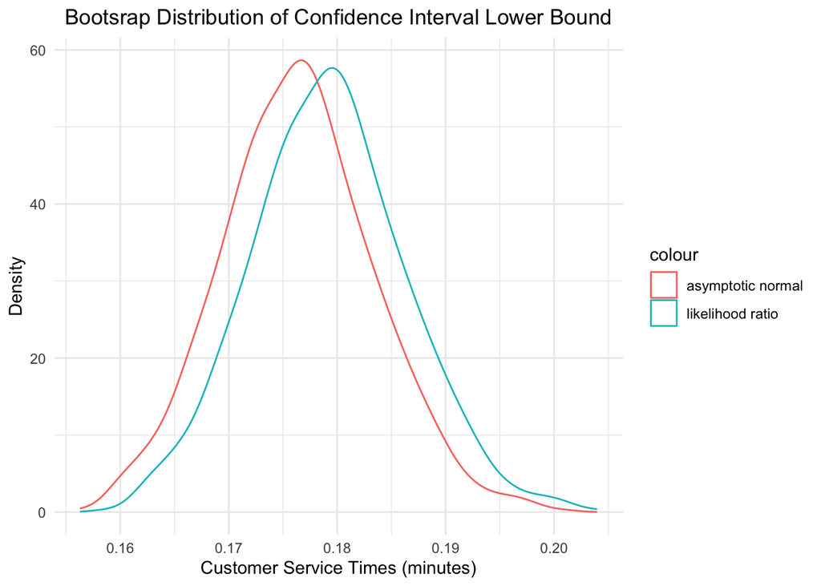

```r
asympotic_CI <- function(X){
  theta_hat <- theta_mle(X)
  var_mle <- 1 / fisher_information(theta_hat) / length(X)
  z <- qnorm(0.975)
  c(theta_hat - z * sqrt(var_mle), theta_hat + z * sqrt(var_mle))
}

likelihood_ratio_CI <- function(X){

  l <- log_likelihood(X)
  theta_hat <- theta_mle(X)
  bounds <- asympotic_CI(X)

  #function signature from above:
  #find_ratio_CI(X, log_likelihood(X), theta_hat, upper_bound)
  find_ratio_CI(X, log_likelihood(X), theta_hat, bounds[2])
}

CI <- function(X){
  c(asympotic_CI(X), likelihood_ratio_CI(X))
}


replicant_n <- 1000

boostrap_sample_iteration <- function(X,  estimator){
  sample_i <- sample(X, size=length(X), replace=TRUE)
  estimator(sample_i)
}

#simplify=TRUE param gives us vector as output
bootstrap_estimator_dist <- replicate(n=replicant_n, expr=boostrap_sample_iteration(X, CI), simplify=TRUE)
bootstrap_df <- data.frame(t(bootstrap_estimator_dist))
colnames(bootstrap_df) <- c("l_asym", "u_asym","l_rat", "u_rat")


ggplot(data=bootstrap_df)+
  geom_density(aes(x=l_asym, color="asymptotic normal")) +
  geom_density(aes(x=l_rat, color="likelihood ratio")) +
  labs(title="Bootsrap Distribution of Confidence Interval Lower Bound", x="Customer Service Times (minutes)", y="Density") +
  theme_minimal() +
  theme(plot.title = element_text(hjust = 0.5))
```

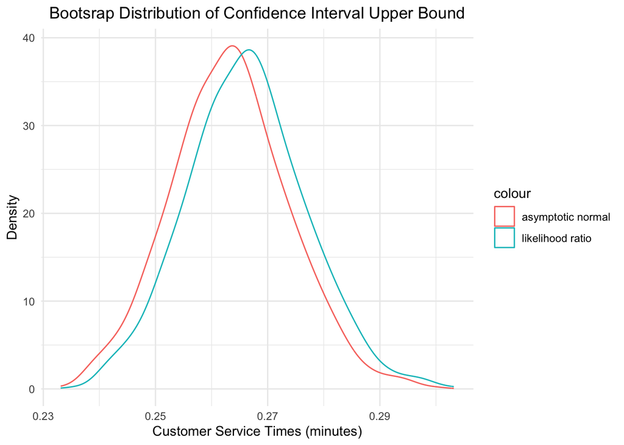

```r
ggplot(data=bootstrap_df)+
  geom_density(aes(x=u_asym, color="asymptotic normal")) +
  geom_density(aes(x=u_rat, color="likelihood ratio")) +
  labs(title="Bootsrap Distribution of Confidence Interval Upper Bound", x="Customer Service Times (minutes)", y="Density") +
  theme_minimal() +
  theme(plot.title = element_text(hjust = 0.5))
```

From the looking at the bootstrap distribution of these two confidence intervals, they both appear visually similar in their variance (spread), but there appears to be some bias somewhere in these methods of finding CI bounds. The plots appear shifted. In terms of giving a recommendation, I would have to do more work to see where the bias is coming from. Assuming both methods are valid though, I would recommend the asymptotic normal method, because of its simplicity compared to the likelihood ratio. Both of the method appear to have intervals of similar width.